# Appropriation des données

Histogramme des distances au transect et fonction de détection

Léa Pautrel

# 1 Importation des données

# 2 Distances au transect

## 2.1 Histogramme : comptage

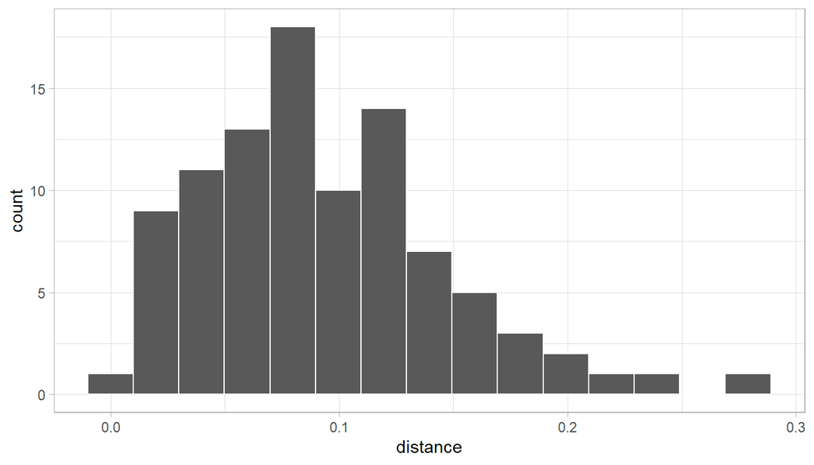

## 2.2 Histogramme : densité

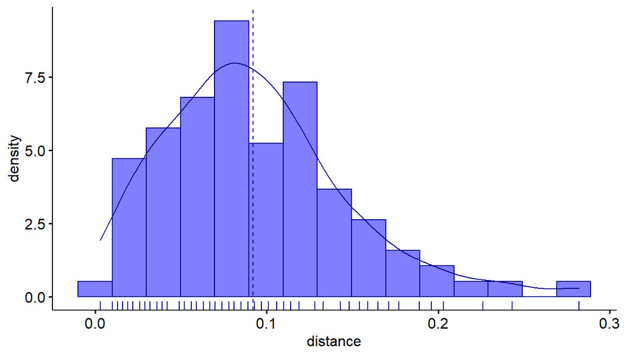

## 2.3 Calcul de la fonction de détection : sans covariables

### 2.3.1 Comparaison des effets des différentes loi pour la vraisemblance

Création d’une fonction `compare_loi_vrais` qui prend en arguments le tableau de données et la formula (`distance ~ 1` ou `distance ~ covar1 + covar2`), et renvoie un graphique qui compare les 5 lois de distributions disponibles pour la vraisemblance.

Remarque : pointSurvey = FALSE car transects

Sans covariables, on obtient ceci :

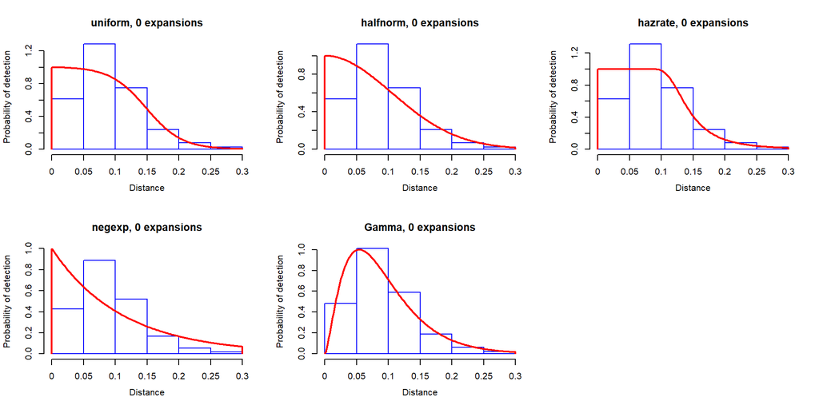

## 2.4 Fonction de détection : ajout des covariables

```r
head(obsdata[,c(3,5,6)])
```

```
##    Transect.Label   Seg Sample.Label
## 13         N1/102 372_2        167_2
## 29         N1/103 382_2        172_2
## 30         N1/103 384_2        172_2
## 53         N1/104 396_2        180_2
## 54         N1/104 396_2        180_2
## 55         N1/104 397_2        180_2
```

Dans obsdata, on a aussi les segments de transect `Seg` et le `Sample.Label`. On pourra donc lier les données obs et les données covariables sur l’une de ces variables.

```r
cov_segment <- predata_output$segdata
dim(cov_segment)
```

```
## [1] 1368   23
```

```r
head(cov_segment[, c(3,5,4)])
```

```
##   Transect.Label   Seg Sample.Label
## 1         N1/204 113_1         49_1
## 2         N1/204 114_1         50_1
## 3         N1/205 139_1         59_1
## 4         N1/403 649_2        303_2
## 5         N1/403 650_2        304_2
## 6         N1/404 656_2        307_2
```

On va alors pouvoir récupérer plusieurs covariables intéressantes :

```
## # A tibble: 3 x 9
##   depth distCoast dist200 slopeP CHL_4w_mea CHL_4w_sd SST_4w_mea SST_4w_sd
##   <dbl>     <dbl>   <dbl>  <dbl>      <dbl>     <dbl>      <dbl>     <dbl>
## 1     2     1572.  137043 22946.       1.17    0.18         11.3     0.800
## 2    16     4252.  133137 36000        1.04    0.0153       11.5     0.997
## 3     2     1702.  143787 10607.       1.40    0.459        11.1     0.768
## # ... with 1 more variable: POC_4w_mea <dbl>
```

- La profondeur `depth`
- La distance par rapport à la côte `distCoast`
- ?? `dist200`
- La pente `slopeP`
- ?? `CHL_4w_mea` `CHL_4w_sd` `SST_4w_mea` `SST_4w_sd` `POC_4w_mea`

### 2.4.1 Manipulation des données : création d’une table avec les observations et les covariables

**Quelle est la clé unique de cov_segment ? Seg ou Sample.Label ?**

```r
nrow(cov_segment)
```

```
## [1] 1368
```

```r
nrow(distinct(cov_segment, Seg))
```

```
## [1] 1368
```

```r
nrow(distinct(cov_segment, Sample.Label))
```

```
## [1] 675
```

Il s’agit de Seg. On va donc joindre sur Seg. On obtient le tableau suivant

|  | Transect.Label | Seg | Sample.Label.x | observerId | session | object | date | survey | distance | size | Effort | X | Y | longitude | latitude | Region.Label.y | seaState | Area | subjective | depth | distCoast | dist200 | slopeP | CHL_4w_mea | CHL_4w_sd | SST_4w_mea | SST_4w_sd | POC_4w_mea |
| --- | --- | --- | --- | --- | --- | --- | --- | --- | --- | --- | --- | --- | --- | --- | --- | --- | --- | --- | --- | --- | --- | --- | --- | --- | --- | --- | --- | --- |
| 1 | N1/102 | 372_2 | 167_2 | VR | 2 | 1449 | 2019-05-31 | Pertuis | 0.133 | 1 | 8.34052 | 286438.648609908 | 6598009.02923849 | -2.38253 | 46.3551 | ATL_N1 | 2 | 14947 | GM | 49 | 36169.3 | 79460.3 | 10606.6 | 1.78043 | 1.03508 | 14.7482 | 1.50603 | 269.658 |
| 2 | N1/103 | 382_2 | 172_2 | SL | 2 | 1397 | 2019-05-31 | Pertuis | 0.067 | 1 | 9.86743 | 281330.847115261 | 6578912.9557907 | -2.43173 | 46.1804 | ATL_N1 | 3 | 14947 | GG | 47 | 55735.3 | 76982.7 | 90697.3 | 3.49643 | 1.617706 | 13.9794 | 1.40079 | 416.072 |
| 3 | N1/103 | 384_2 | 172_2 | SL | 2 | 1409 | 2019-05-31 | Pertuis | 0.097 | 1 | 9.86743 | 261924.984240784 | 6575382.18497139 | -2.67936 | 46.1364 | ATL_N1 | 3 | 14947 | GG | 108 | 64955.9 | 57037.3 | 56364.9 | 1.33684 | 0.599681 | 14.7223 | 1.55323 | 191.493 |
| 4 | N1/104 | 396_2 | 180_2 | GD | 2 | 1233 | 2019-05-30 | Pertuis | 0.042 | 1 | 9.98422 | 277222.888532842 | 6550533.03811852 | -2.45944 | 45.9229 | ATL_N1 | 1 | 14947 | GG | 120 | 78606.5 | 63620.7 | 64656.8 | 1.00404 | 0.213548 | 15.1279 | 1.47294 | 173.737 |
| 5 | N1/104 | 396_2 | 180_2 | GD | 2 | 1242 | 2019-05-30 | Pertuis | 0.026 | 1 | 9.98422 | 277222.888532842 | 6550533.03811852 | -2.45944 | 45.9229 | ATL_N1 | 1 | 14947 | GG | 120 | 78606.5 | 63620.7 | 64656.8 | 1.00404 | 0.213548 | 15.1279 | 1.47294 | 173.737 |
| 6 | N1/104 | 397_2 | 180_2 | GD | 2 | 1243 | 2019-05-30 | Pertuis | 0.056 | 1 | 9.98422 | 268288.922375227 | 6546092.88514591 | -2.57039 | 45.8774 | ATL_N1 | 1 | 14947 | GG | 100 | 88130.6 | 56352.6 | 12369.3 | 0.903372 | 0.1246 | 15.0185 | 1.59357 | 169.875 |
| 7 | N1/104 | 397_2 | 180_2 | GD | 2 | 1244 | 2019-05-30 | Pertuis | 0.085 | 1 | 9.98422 | 268288.922375227 | 6546092.88514591 | -2.57039 | 45.8774 | ATL_N1 | 1 | 14947 | GG | 100 | 88130.6 | 56352.6 | 12369.3 | 0.903372 | 0.1246 | 15.0185 | 1.59357 | 169.875 |
| 8 | N1/104 | 397_2 | 180_2 | GD | 2 | 1247 | 2019-05-30 | Pertuis | 0.056 | 1 | 9.98422 | 268288.922375227 | 6546092.88514591 | -2.57039 | 45.8774 | ATL_N1 | 1 | 14947 | GG | 100 | 88130.6 | 56352.6 | 12369.3 | 0.903372 | 0.1246 | 15.0185 | 1.59357 | 169.875 |
| 9 | N1/104 | 397_2 | 180_2 | GD | 2 | 1250 | 2019-05-30 | Pertuis | 0.013 | 1 | 9.98422 | 268288.922375227 | 6546092.88514591 | -2.57039 | 45.8774 | ATL_N1 | 1 | 14947 | GG | 100 | 88130.6 | 56352.6 | 12369.3 | 0.903372 | 0.1246 | 15.0185 | 1.59357 | 169.875 |
| 10 | N1/104 | 398_2 | 180_2 | GD | 2 | 1256 | 2019-05-30 | Pertuis | 0.059 | 1 | 9.98422 | 259353.984786697 | 6541642.63378927 | -2.68116 | 45.8317 | ATL_N1 | 1 | 14947 | GG | 112 | 96780.9 | 49436.3 | 10606.6 | 0.866382 | 0.1246 | 14.9481 | 1.62769 | 170.255 |

[output cut: 86 more lines]

# 3 Fonctions de détection avec covariables

## 3.1 Fonction de détection en fonction de l’état de la mer

```r
# Initialisation
formula <- "distance ~ seaState"
sharkDetectionData <- data.frame("Seg" = obs_cov_sample$Seg,
                                                        "groupsize" = obs_cov_sample$size,
                                                        "distance" = obs_cov_sample$distance)
head(sharkDetectionData)
```

```
##     Seg groupsize distance
## 1 372_2         1    0.133
## 2 382_2         1    0.067
## 3 384_2         1    0.097
## 4 396_2         1    0.042
## 5 396_2         1    0.026
## 6 397_2         1    0.056
```

```r
sharkSiteData <- data.frame("Seg" = obs_cov_sample$Seg,
                                             "seaState" = as.factor(obs_cov_sample$seaState))
head(sharkSiteData)
```

```
##     Seg seaState
## 1 372_2        2
## 2 382_2        3
## 3 384_2        3
## 4 396_2        1
## 5 396_2        1
## 6 397_2        1
```

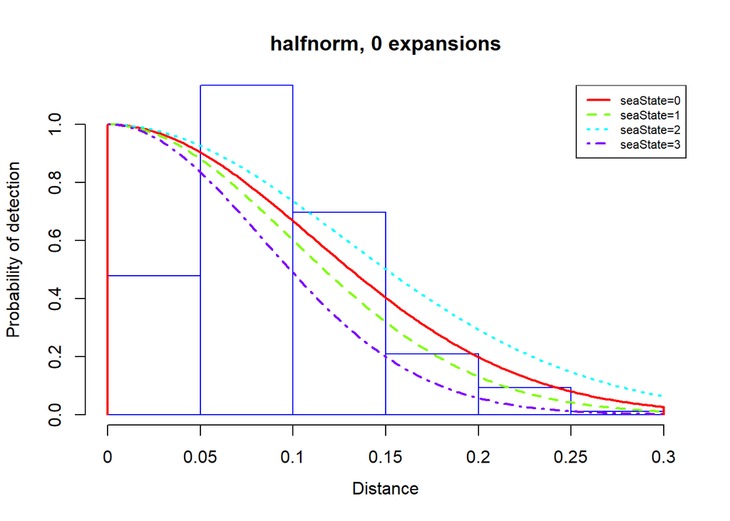

```r
# Estimation de la fonction de détection
shark_dfunc <- Rdistance::dfuncEstim(
    formula = formula,
    detectionData = sharkDetectionData,
    siteData = sharkSiteData,
    likelihood = "halfnorm",
    w.hi = 0.3,
    pointSurvey = FALSE
)

# Affichage
plot(shark_dfunc,
         newdata = data.frame(seaState = levels(sharkSiteData$seaState)))
```

## 3.2 Fonction de détection en fonction de la profondeur, la distance par rapport à la côte et la pente

```
##     Seg groupsize distance
## 1 372_2         1    0.133
## 2 382_2         1    0.067
## 3 384_2         1    0.097
## 4 396_2         1    0.042
## 5 396_2         1    0.026
## 6 397_2         1    0.056
```

```
##     Seg  depth distCoast slopeP
## 1 372_2 Faible    Faible Faible
## 2 382_2 Faible     Moyen  Moyen
## 3 384_2  Eleve     Moyen  Moyen
## 4 396_2  Eleve     Eleve  Moyen
## 5 396_2  Eleve     Eleve  Moyen
## 6 397_2  Moyen     Eleve Faible
```

### 3.2.1 depth (profondeur)

```
## Call: Rdistance::dfuncEstim(formula = "distance ~ depth", detectionData
##    = sharkDetectionData, siteData = sharkSiteData, likelihood =
##    "halfnorm", pointSurvey = FALSE, w.hi = 0.3)
## Coefficients:
##              Estimate    SE         z           p(>|z|)
## (Intercept)  -1.9919589  0.1896227  -10.504856  8.204798e-26
## depthMoyen   -0.2802999  0.1976271   -1.418327  1.560952e-01
## depthEleve   -0.3545743  0.2309222   -1.535471  1.246681e-01
##
## Convergence: Success
## Function: HALFNORM
## Strip: 0 to 0.3
## Average effective strip width (ESW): 0.1316001
## Average probability of detection: 0.4386671
## Scaling: g(0) = 1
## Log likelihood: -391.757
## AICc: -777.4172
```

### 3.2.2 distCoast

```
## Call: Rdistance::dfuncEstim(formula = "distance ~ distCoast",
##    detectionData = sharkDetectionData, siteData = sharkSiteData,
##    likelihood = "halfnorm", pointSurvey = FALSE, w.hi = 0.3)
## Coefficients:
##                 Estimate     SE         z           p(>|z|)
## (Intercept)     -2.38015876  0.2812472  -8.4628721  2.608719e-17
## distCoastMoyen   0.17885724  0.2894508   0.6179194  5.366285e-01
## distCoastEleve   0.07102713  0.2909505   0.2441210  8.071371e-01
##
## Convergence: Success
## Function: HALFNORM
## Strip: 0 to 0.3
## Average effective strip width (ESW): 0.1315544
## Average probability of detection: 0.4385145
## Scaling: g(0) = 1
## Log likelihood: -390.7727
## AICc: -775.4486
```

### 3.2.3 slopeP

```
## Call: Rdistance::dfuncEstim(formula = "distance ~ slopeP",
##    detectionData = sharkDetectionData, siteData = sharkSiteData,
##    likelihood = "halfnorm", pointSurvey = FALSE, w.hi = 0.3)
## Coefficients:
##              Estimate    SE          z            p(>|z|)
## (Intercept)  -2.2584074  0.05185139  -43.5553846  0.0000000
## slopePMoyen   0.1028359  0.17187471    0.5983187  0.5496273
## slopePEleve  -0.9861633  0.70874102   -1.3914297  0.1640952
##
## Convergence: Success
## Function: HALFNORM
## Strip: 0 to 0.3
## Average effective strip width (ESW): 0.1315068
## Average probability of detection: 0.4383561
## Scaling: g(0) = 1
## Log likelihood: -390.862
## AICc: -775.6273
```

### 3.2.4 depth (p) + distCoast

```
## Call: Rdistance::dfuncEstim(formula = "distance ~ depth + distCoast",
##    detectionData = sharkDetectionData, siteData = sharkSiteData,
##    likelihood = "halfnorm", pointSurvey = FALSE, w.hi = 0.3)
## Coefficients:
##                 Estimate    SE         z          p(>|z|)
## (Intercept)     -2.3804173  0.2810962  -8.468335  2.489248e-17
## depthMoyen      -0.3997394  0.2706838  -1.476776  1.397356e-01
## depthEleve      -0.4588878  0.3050820  -1.504146  1.325438e-01
## distCoastMoyen   0.5230251  0.3841133   1.361643  1.733107e-01
## distCoastEleve   0.4853400  0.3987267   1.217225  2.235187e-01
##
## Convergence: Success
## Function: HALFNORM
## Strip: 0 to 0.3
## Average effective strip width (ESW): 0.1316837
## Average probability of detection: 0.4389456
## Scaling: g(0) = 1
## Log likelihood: -392.6476
## AICc: -775.0512
```

### 3.2.5 depth (p) + slopeP

```
## Call: Rdistance::dfuncEstim(formula = "distance ~ depth + slopeP",
##    detectionData = sharkDetectionData, siteData = sharkSiteData,
##    likelihood = "halfnorm", pointSurvey = FALSE, w.hi = 0.3)
## Coefficients:
##              Estimate     SE         z           p(>|z|)
## (Intercept)  -2.00267717  0.2036575  -9.8335571  8.071632e-23
## depthMoyen   -0.26784748  0.2093399  -1.2794858  2.007261e-01
## depthEleve   -0.35175190  0.2320070  -1.5161259  1.294875e-01
## slopePMoyen   0.02724831  0.1917187   0.1421265  8.869801e-01
## slopePEleve  -0.97354717  0.7094096  -1.3723343  1.699594e-01
##
## Convergence: Success
## Function: HALFNORM
## Strip: 0 to 0.3
## Average effective strip width (ESW): 0.1315332
## Average probability of detection: 0.438444
## Scaling: g(0) = 1
## Log likelihood: -392.3082
## AICc: -774.3725
```

### 3.2.6 distCoast + slopeP

```
## Call: Rdistance::dfuncEstim(formula = "distance ~ distCoast + slopeP",
##    detectionData = sharkDetectionData, siteData = sharkSiteData,
##    likelihood = "halfnorm", pointSurvey = FALSE, w.hi = 0.3)
## Coefficients:
##                 Estimate     SE         z           p(>|z|)
## (Intercept)     -2.38039428  0.2811830  -8.4656414  2.547468e-17
## distCoastMoyen   0.16774295  0.2900720   0.5782805  5.630748e-01
## distCoastEleve   0.06912869  0.2912694   0.2373359  8.123962e-01
## slopePMoyen      0.08582121  0.1726920   0.4969613  6.192164e-01
## slopePEleve     -0.93289376  0.7111769  -1.3117605  1.896010e-01
##
## Convergence: Success
## Function: HALFNORM
## Strip: 0 to 0.3
## Average effective strip width (ESW): 0.1314761
## Average probability of detection: 0.4382536
## Scaling: g(0) = 1
## Log likelihood: -391.4178
## AICc: -772.5917
```

### 3.2.7 depth (p) + distCoast + slopeP

```
## Call: Rdistance::dfuncEstim(formula = "distance ~ depth + distCoast +
##    slopeP", detectionData = sharkDetectionData, siteData =
##    sharkSiteData, likelihood = "halfnorm", pointSurvey = FALSE, w.hi =
##    0.3)
## Coefficients:
##                 Estimate     SE         z            p(>|z|)
## (Intercept)     -2.37993390  0.2813107  -8.46016133  2.670079e-17
## depthMoyen      -0.40486925  0.2784354  -1.45408703  1.459222e-01
## depthEleve      -0.46419000  0.3042019  -1.52592710  1.270280e-01
## distCoastMoyen   0.52863524  0.3913021   1.35096437  1.767068e-01
## distCoastEleve   0.49605530  0.4051024   1.22451841  2.207567e-01
## slopePMoyen     -0.01638053  0.1957687  -0.08367284  9.333165e-01
## slopePEleve     -0.95459606  0.7127110  -1.33938726  1.804446e-01
##
## Convergence: Success
## Function: HALFNORM
## Strip: 0 to 0.3
## Average effective strip width (ESW): 0.131586
## Average probability of detection: 0.4386201
## Scaling: g(0) = 1
## Log likelihood: -393.1748
## AICc: -771.8905
```

### 3.2.8 Resultats graphiques

**Résultats**

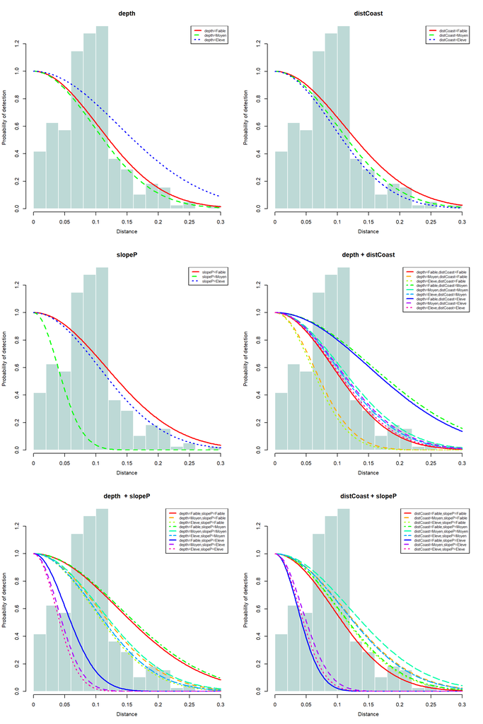

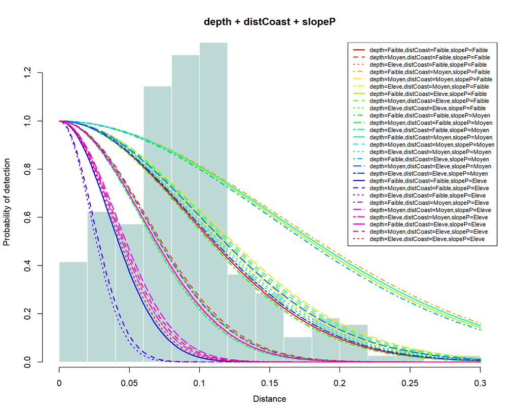